# stat506hw3

## Problem 1 - Vision

a. Download the file and merge into the single data using SEQN Variable.

- import sasxport5 “I:\Fall 2023\STATS 506\PS3\VIX_D.XPT”, clear
- save “I:\Fall 2023\STATS 506\PS3\VIX_D.dta”, replace
- file I:\Fall 2023\STATS 506\PS3\VIX_D.dta saved
- import sasxport5 “I:\Fall 2023\STATS 506\PS3\DEMO_D.XPT”, clear
- save “I:\Fall 2023\STATS 506\PS3\DEMO_D.dta”, replace
- file I:\Fall 2023\STATS 506\PS3\DEMO_D.dta saved
- use “I:\Fall 2023\STATS 506\PS3\VIX_D.dta”
- merge 1:1 seqn using “I:\Fall 2023\STATS 506\PS3\DEMO_D.dta”

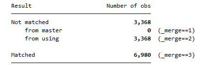

- . keep if _merge==3

(3,368 observations deleted)

b)

- gen age_bracket = floor(ridageyr / 10) * 10
- collapse (mean) wear_glasses = viq220 (count) total = viq220, by(age_bracket)
- list age_bracket wear_glasses

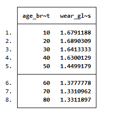

c) Logistic Regression

**Model 1: age**

- logistic viq220 ridageyr

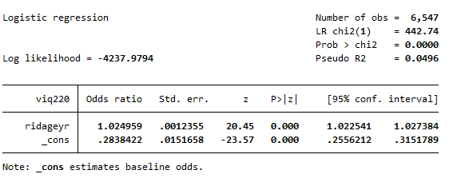

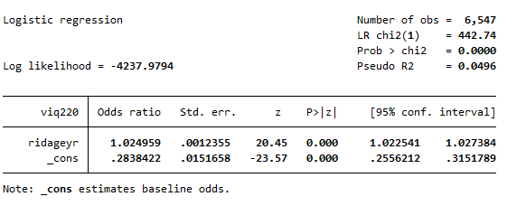

- logit viq220 ridageyr

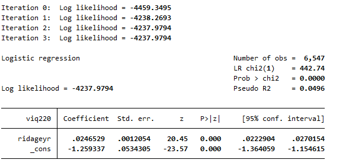

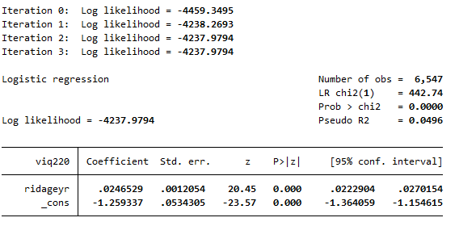

- estat ic

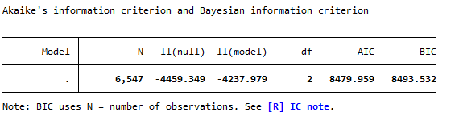

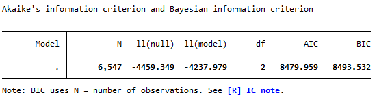

- estimates store Model1

**Model 2: age, race, gender**

- logistic viq220 ridageyr ridreth1 riagendr

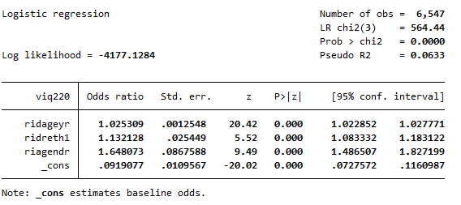

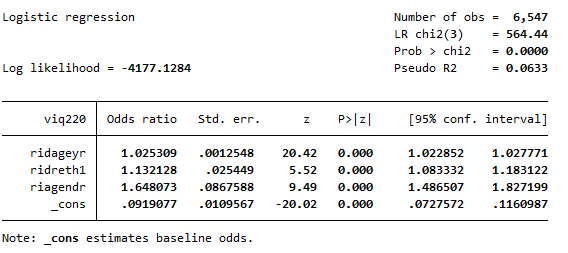

- logit viq220 ridageyr ridreth1 riagendr

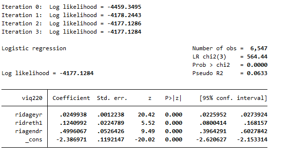

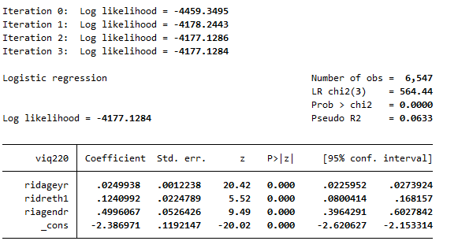

- estat ic

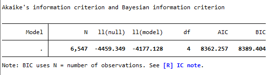

- estimates store Model2

**Model 3 age, race, gender, Poverty Income ratio**

- logistic viq220 ridageyr ridreth1 riagendr indfmpir

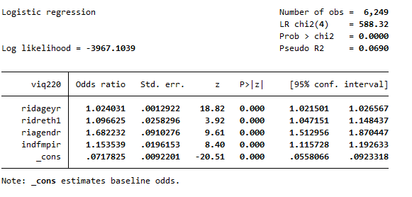

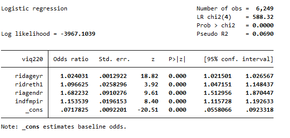

- logit viq220 ridageyr ridreth1 riagendr indfmpir

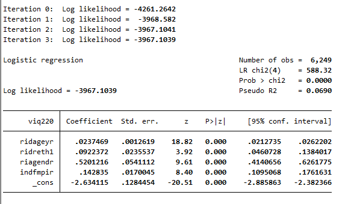

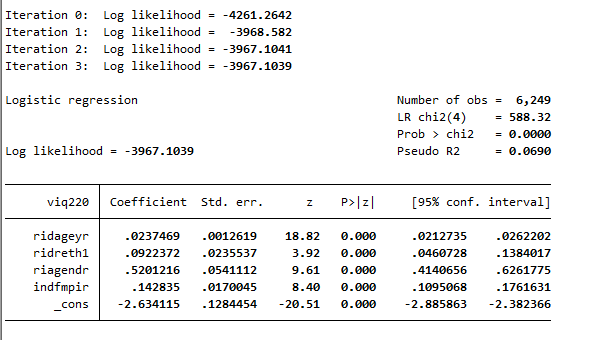

- estat ic

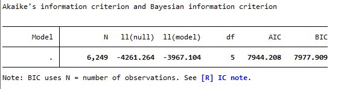

- estimates store Model3
- esttab Model1 Model2 Model3, b aic pr2

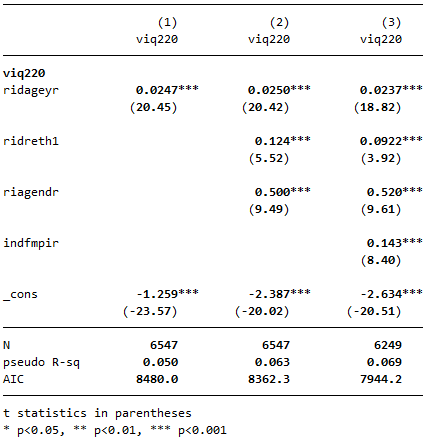

[figure not shown]

  d) We can use chi-square test to measure the goodness of fit.
- tabulate riagendr viq220, chi2

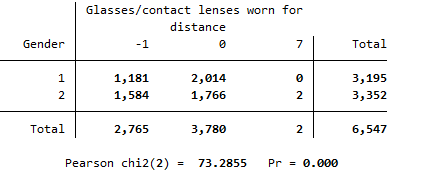

If we look at the chi-square test and p-value, it is almost equal to 0. We can conclude that there is a statistically significant difference between the glasses wear between men and women.

## Problem 2

```r
library(DBI)
library(RSQLite)
```

```r
sakila <- dbConnect(RSQLite::SQLite(), "/Users/katherinemin/Downloads/sakila_master.db")
dbListTables(sakila)
```

```
##  [1] "actor"                  "address"                "category"
##  [4] "city"                   "country"                "customer"
##  [7] "customer_list"          "film"                   "film_actor"
## [10] "film_category"          "film_list"              "film_text"
## [13] "inventory"              "language"               "payment"
## [16] "rental"                 "sales_by_film_category" "sales_by_store"
## [19] "staff"                  "staff_list"             "store"
```

```r
#create function to execute dbGetQuery
gg <- function(x) {
  dbGetQuery(sakila, x)
}
```

###Question (a)

```r
# Define the SQL query to merge film and langauge by language_id
query <- "
SELECT f.*, l.name AS language_name
FROM film AS f
LEFT JOIN language AS l ON f.language_id = l.language_id
"

# Execute the query and retrieve the result
result <- dbGetQuery(sakila, query)

# Print the merged result
print(result)
```

```
##      film_id                       title
## 1          1            ACADEMY DINOSAUR
## 2          2              ACE GOLDFINGER
## 3          3            ADAPTATION HOLES
## 4          4            AFFAIR PREJUDICE
## 5          5                 AFRICAN EGG
## 6          6                AGENT TRUMAN
## 7          7             AIRPLANE SIERRA
## 8          8             AIRPORT POLLOCK
## 9          9               ALABAMA DEVIL
## 10        10            ALADDIN CALENDAR
## 11        11             ALAMO VIDEOTAPE
## 12        12              ALASKA PHANTOM
## 13        13                 ALI FOREVER
## 14        14              ALICE FANTASIA
```

[output cut: 5991 more lines]

```r
# Load necessary libraries
library(dplyr)
#Find the most common language using dyplyr through grouping the tables by language name
most_common_language <- result %>%
  group_by(language_name) %>%
  summarize(film_count = n()) %>%
  arrange(desc(film_count))

print(most_common_language)
```

```
## # A tibble: 1 × 2
##   language_name film_count
##   <chr>              <int>
## 1 English             1000
```

```r
#Also can check that the dataset only consists of movies in English
sum((result$language_name=="English"))
```

```
## [1] 1000
```

There is no other langauge more common than English in the dataset.

###Question (b)

```r
gg("SELECT c.name AS genre_name, COUNT(*) AS movie_count
FROM film_category AS fc
INNER JOIN category AS c ON fc.category_id = c.category_id
GROUP BY c.name
ORDER BY movie_count DESC
LIMIT 1;")
```

```
##   genre_name movie_count
## 1     Sports          74
```

```r
# Find the most common genre and its count using R
#library(tidyverse)

movie = gg("SELECT *
   FROM film_category")
category = gg("SELECT *
              FROM category")

genre = merge(x=movie, y=category, by="category_id", all.x=TRUE)

most_common_genre = aggregate(genre$film_id, by=list(genre$name), FUN=length)
most_common_genre[order(most_common_genre$x, decreasing=TRUE),]
```

```
##        Group.1  x
## 15      Sports 74
## 9      Foreign 73
## 8       Family 69
## 6  Documentary 68
## 2    Animation 66
## 1       Action 64
## 13         New 63
## 7        Drama 62
## 10       Games 61
## 14      Sci-Fi 61
## 3     Children 60
## 5       Comedy 58
## 4     Classics 57
## 16      Travel 57
## 11      Horror 56
## 12       Music 51
```

We can see that sports is the most common genre.

###Question (c)

```r
gg("SELECT country, COUNT(*) AS customer_count
FROM (
    SELECT c.country, COUNT(*) AS customer_count
    FROM customer AS cu
    INNER JOIN address AS a ON cu.address_id = a.address_id
    INNER JOIN city AS ci ON a.city_id = ci.city_id
    INNER JOIN country AS c ON ci.country_id = c.country_id
    GROUP BY c.country_id, c.country
) AS merged
GROUP BY country
HAVING customer_count = 9;")
```

```
##          country customer_count
## 1 United Kingdom              1
```

```r
# Combine data from customer, address, city, and country tables into a single DataFrame
query <- "
SELECT c.*, a.*, ci.*, co.*
FROM customer AS c
JOIN address AS a ON c.address_id = a.address_id
JOIN city AS ci ON a.city_id = ci.city_id
JOIN country AS co ON ci.country_id = co.country_id
"
combined_data <- dbGetQuery(sakila, query)

# Find which country has exactly 9 customers
country_counts <- table(combined_data$country)
countries_with_9_customers <- names(country_counts[country_counts == 9])

print(countries_with_9_customers)
```

```
## [1] "United Kingdom"
```

UK is the country that has 9 customers.

## Problem 3

```r
#Import the dataset
us500<-read.csv("/Users/katherinemin/Downloads/us-500.csv")
head(us500)
```

```
##   first_name last_name           company_name              address        city
## 1      James      Butt      Benton, John B Jr   6649 N Blue Gum St New Orleans
## 2  Josephine   Darakjy  Chanay, Jeffrey A Esq  4 B Blue Ridge Blvd    Brighton
## 3        Art    Venere    Chemel, James L Cpa 8 W Cerritos Ave #54  Bridgeport
## 4      Lenna  Paprocki Feltz Printing Service          639 Main St   Anchorage
## 5    Donette    Foller    Printing Dimensions         34 Center St    Hamilton
## 6     Simona   Morasca    Chapman, Ross E Esq         3 Mcauley Dr     Ashland
##       county state   zip       phone1       phone2
## 1    Orleans    LA 70116 504-621-8927 504-845-1427
## 2 Livingston    MI 48116 810-292-9388 810-374-9840
## 3 Gloucester    NJ  8014 856-636-8749 856-264-4130
## 4  Anchorage    AK 99501 907-385-4412 907-921-2010
## 5     Butler    OH 45011 513-570-1893 513-549-4561
## 6    Ashland    OH 44805 419-503-2484 419-800-6759
##                           email                                 web
## 1               jbutt@gmail.com        http://www.bentonjohnbjr.com
## 2 josephine_darakjy@darakjy.org    http://www.chanayjeffreyaesq.com
## 3                art@venere.org      http://www.chemeljameslcpa.com
## 4         lpaprocki@hotmail.com http://www.feltzprintingservice.com
## 5        donette.foller@cox.net   http://www.printingdimensions.com
## 6            simona@morasca.com      http://www.chapmanrosseesq.com
```

###Question (a)

```r
# Count the number of email addresses with ".net" TLD
num_net_emails <- sum(grepl("@[A-Za-z0-9.-]+\\.net", us500$email))

# Calculate the proportion
proportion_net <- num_net_emails / nrow(us500)

# Print the result
cat("Proportion of email addresses with '.net' TLD:", proportion_net, "\n")
```

```
## Proportion of email addresses with '.net' TLD: 0.14
```

###Question (b)

```r
# Function to check if an email address has at least one non-alphanumeric character
has_non_alphanumeric <- function(email) {
  # Use regular expression to match non-alphanumeric characters (excluding "@" and ".")
  non_alphanumeric <- grep("[^A-Za-z0-9@.]", email)
  # If any non-alphanumeric character is found, return TRUE, otherwise, return FALSE
  return(length(non_alphanumeric) > 0)
}

# Apply the function to each email address in the dataset and count the number of emails with non-alphanumeric characters
num_emails_with_non_alphanumeric <- sum(sapply(us500$email, has_non_alphanumeric))

# Calculate the proportion
proportion_non_alphanumeric <- num_emails_with_non_alphanumeric / nrow(us500)

# Print the result
cat("Proportion of email addresses with non-alphanumeric characters (excluding '@' and '.'):",
    proportion_non_alphanumeric, "\n")
```

```
## Proportion of email addresses with non-alphanumeric characters (excluding '@' and '.'): 0.248
```

###Question (c)

```r
# Combine phone1 and phone2 columns into a single vector
phone_numbers <- c(us500$phone1, us500$phone2)

# Extract the area code (first 3 digits) from each phone number using regular expressions
area_codes <- gsub("^(\\d{3}).*$", "\\1", phone_numbers)

# Calculate the frequency of each area code
area_code_counts <- table(area_codes)

# Find the most common area code
most_common_area_code <- names(area_code_counts[which.max(area_code_counts)])

cat("The most common area code among all phone numbers is:", most_common_area_code, "\n")
```

```
## The most common area code among all phone numbers is: 973
```

###Question (D)

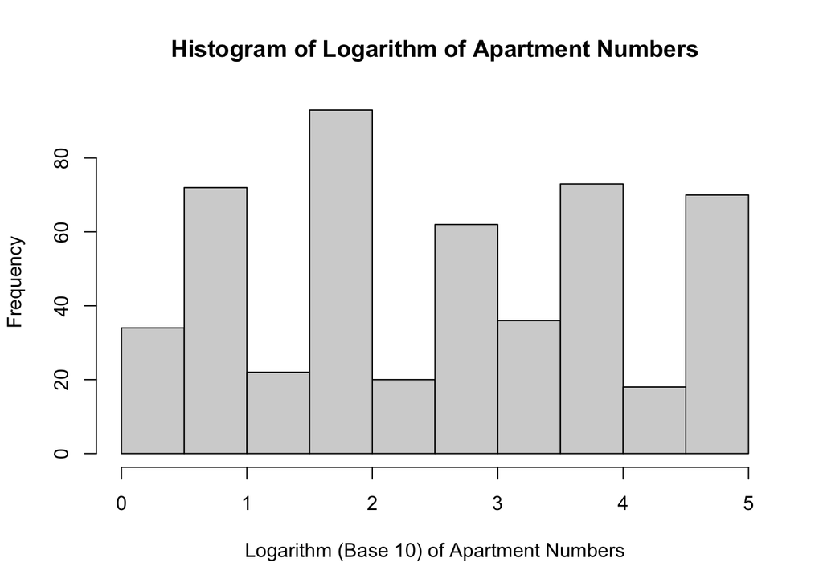

```r
library (dplyr)
library(stringr)

# Extract apartment numbers using regular expressions and take the logarithm
apartment_numbers <- us500$address %>%
  # Extract apartment numbers using regular expression
  str_extract("\\b\\d+\\b") %>%
  # Remove NAs (addresses with no apartment numbers)
  na.omit() %>%
  # Convert to numeric and take the logarithm (base 10)
  as.numeric() %>%
  log10()

# Create a histogram of the logarithm of apartment numbers
hist(apartment_numbers, main = "Histogram of Logarithm of Apartment Numbers",
     xlab = "Logarithm (Base 10) of Apartment Numbers")
```

###Question (e)

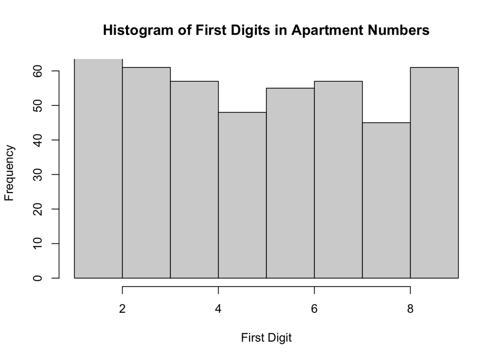

```r
# Extract the apartment numbers (last couple of numbers before # sign)
apartment_numbers <- gsub(".*#(\\d+)$", "\\1", us500$address)

# Remove NAs (addresses with no apartment numbers)
apartment_numbers <- apartment_numbers[!is.na(apartment_numbers)]

# Extract the first digit from the apartment numbers
first_digits <- as.numeric(substr(apartment_numbers, 1, 1))

# Create a histogram of the first digits
hist(first_digits, main = "Histogram of First Digits in Apartment Numbers",
     xlab = "First Digit", ylim = c(0, max(table(first_digits))))
```

We can see that it does not follow the Benford’s law as the distribution is spread out evenly among each digit.

###Question (f)

```r
# Extract apartment numbers (numbers after # sign)
apartment_numbers <- gsub(".*#(\\d+).*", "\\1", us500$address)

# Remove NAs (addresses with no apartment numbers)
apartment_numbers <- apartment_numbers[!is.na(apartment_numbers)]

# Extract the last digit from apartment numbers
last_digits <- as.numeric(substring(apartment_numbers, nchar(apartment_numbers), nchar(apartment_numbers)))
```

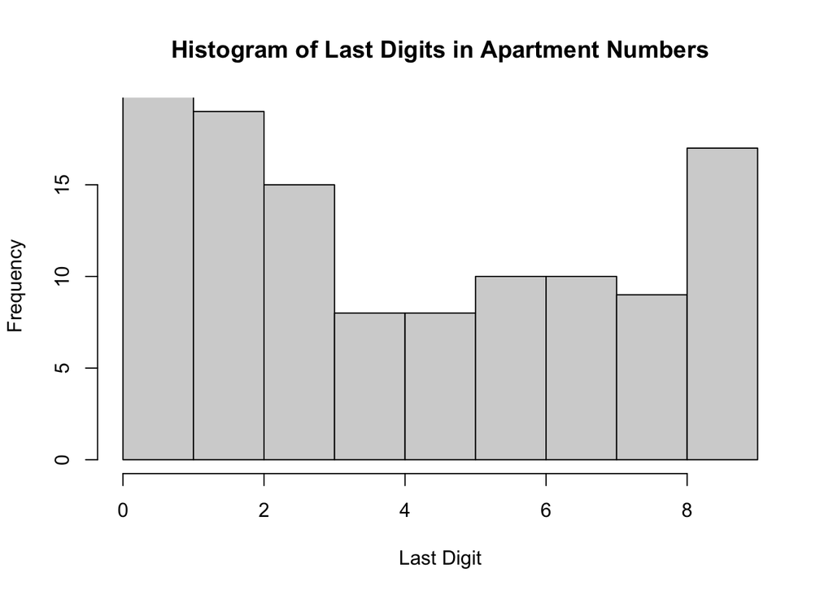

```r
# Create a histogram of the last digits
hist(last_digits, main = "Histogram of Last Digits in Apartment Numbers",
     xlab = "Last Digit", ylim = c(0, max(table(last_digits))))
```

The last digits of apartment numbers somewhat follows the Benford’s Law in a way that the distribution is bimodal and the data points are more focused on the first couple digits.